# Chapter 12 - Dominance relations & specialization

Bodo Winter

8/24/2018

## Introduction

This is the analysis for Chapter 12, the first chapter that uses the Lynott and Connell (2009) norms to make novel theoretical claims. The first part looks at dominance relations between the senses, e.g., which sensory modalities have more words? In part, this recapitulates analyses performed by Lynott and Connell (2009) and Winter, Perlman and Majid (2018). The second part looks at specialization of sensory words, e.g., the degree to which words are multisensory. This analysis goes beyond what has been done by Lynott and Connell (2009) and Lynott and Connell (2013) by providing an adequate statistical baseline for their measure of “modality exclusivity”.

We begin by loading in the data and libraries.

```r
## Libraries:

library(png)        # for plotting sensory modality images
library(diptest)        # for bimodality tests
library(tidyverse)
library(stringr)

## Load data:

lyn <- read_csv('../raw-data/modality_lynott_connell_2009.csv')
noun <- read_csv('../raw-data/modality_lynott_connell_2013.csv')
```

Some more preprocessing:

```r
## Vector of modality names:

mymods <- c('Visual', 'Haptic', 'Auditory',
            'Gustatory', 'Olfactory')

## Load plotting functions:

source('../functions/plot_density.R')
source('../functions/emptyplot.R')
source('../functions/setup_plots.R')
```

This time, we will use the image data (from freepix.com). So let’s load in images and specify the color values.

```r
## Load in images:

s1 <- readPNG('../figures/sight.png')
s2 <- readPNG('../figures/touch.png')
s3 <- readPNG('../figures/sound.png')
s4 <- readPNG('../figures/taste.png')
s5 <- readPNG('../figures/smell.png')

## Define vector of names:

sense_names <- str_c('s', 1:5)

## Define colors:

mycols <- c('#f37058', '#f79038', '#efbe1b',
            '#425fac', '#30b77d')
```

## Average modality ratings per sense

First, let’s look at what the average modality strength rating is, as well as the respective SDs. These are essentially just column-wise summary statistics.

```r
## Compute means:

round(apply(lyn[, str_c(mymods, 'StrengthMean')], 2, mean), 1)
```

```
##    VisualStrengthMean    HapticStrengthMean  AuditoryStrengthMean
##                   3.6                   2.2                   1.5
## GustatoryStrengthMean OlfactoryStrengthMean
##                   1.3                   1.2
```

```r
round(apply(lyn[, str_c(mymods, 'StrengthMean')], 2, sd), 1)
```

```
##    VisualStrengthMean    HapticStrengthMean  AuditoryStrengthMean
##                   1.2                   1.6                   1.6
## GustatoryStrengthMean OlfactoryStrengthMean
##                   1.6                   1.5
```

Next, we will make a simple bar plot:

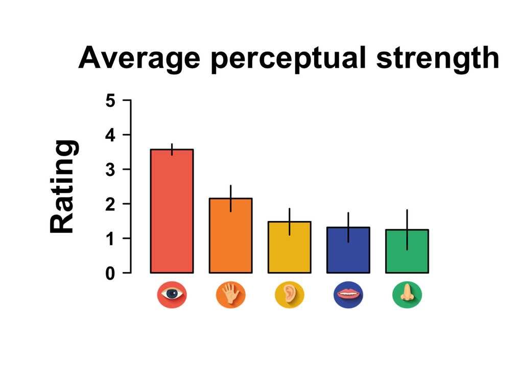

```r
## Get means for plotting:

xmeans <- colMeans(select(lyn,
                          VisualStrengthMean:OlfactoryStrengthMean))

## Get the SDs for plotting:

xsds <- apply(select(lyn,
                     VisualStrengthMean:OlfactoryStrengthMean),
              2, sd)

## Derive standard errors of the mean for plotting:

xNs <- table(lyn$DominantModality)
xNs <- xNs[c('Visual', 'Haptic', 'Auditory', 'Gustatory', 'Olfactory')]

xses <- xsds / sqrt(xNs)

## Set scaling factors:

xfac <- 0.14
rast_fac <- 0.1

## Make the plot:

quartz('', 8.5, 6)
par(mai = c(1.25, 1.75, 1.25, 1))
plot(1, 1,
    type = 'n', xaxt = 'n', yaxt = 'n', xlab = '', ylab = '', bty = 'n',
    xlim = c(1, 6), ylim = c(0, 5))
axis(side = 2, at = seq(0, 5, 1), las = 2,
    font = 2, lwd = 2, lwd.ticks = 2, cex.axis = 1.5)
mtext('Rating', side = 2, line = 3.7, font = 2, cex = 2.5)
mtext('Average perceptual strength',
    side = 3, line = 1.5, font = 2, cex = 2.5)
for (i in 1:5) {
  rect(xleft = i + xfac, xright = i + 1 - xfac,
       ybottom = 0, ytop = xmeans[i],
       col = mycols[i], lwd = 2)

  segments(x0 = mean(c(i + xfac, i + 1 - xfac)),
           y0 = xmeans[i] - 1.96 * xses[i],
           y1 = xmeans[i] + 1.96 * xses[i], lwd = 2)

  rasterImage(get(sense_names[i]),
              xleft = i + xfac + rast_fac,
              xright = i + 1 - xfac - rast_fac,
              ybottom = -1.17 + rast_fac * 1.3,
              ytop = -0.1 - rast_fac * 1.3, xpd = NA)
        }
```

## Wilcoxon tests of differences

In the next section, we perform Wilcoxon tests, first uncorrected, then Dunn-Sidak corrected.

```r
## Wilcoxon-tests on mean differences:

wilcox.test(lyn$VisualStrengthMean,
    lyn$AuditoryStrengthMean, paired = TRUE)
```

```
##
##  Wilcoxon signed rank test with continuity correction
##
## data:  lyn$VisualStrengthMean and lyn$AuditoryStrengthMean
## V = 78898, p-value < 2.2e-16
## alternative hypothesis: true location shift is not equal to 0
```

```r
wilcox.test(lyn$VisualStrengthMean,
    lyn$HapticStrengthMean, paired = TRUE)
```

```
##
##  Wilcoxon signed rank test with continuity correction
##
## data:  lyn$VisualStrengthMean and lyn$HapticStrengthMean
## V = 80016, p-value < 2.2e-16
## alternative hypothesis: true location shift is not equal to 0
```

```r
wilcox.test(lyn$VisualStrengthMean,
    lyn$GustatoryStrengthMean, paired = TRUE)
```

```
##
##  Wilcoxon signed rank test with continuity correction
##
## data:  lyn$VisualStrengthMean and lyn$GustatoryStrengthMean
## V = 81536, p-value < 2.2e-16
## alternative hypothesis: true location shift is not equal to 0
```

```r
wilcox.test(lyn$VisualStrengthMean,
    lyn$OlfactoryStrengthMean, paired = TRUE)
```

```
##
##  Wilcoxon signed rank test with continuity correction
##
## data:  lyn$VisualStrengthMean and lyn$OlfactoryStrengthMean
## V = 80830, p-value < 2.2e-16
## alternative hypothesis: true location shift is not equal to 0
```

```r
wilcox.test(lyn$AuditoryStrengthMean,
    lyn$HapticStrengthMean, paired = TRUE)
```

```
##
##  Wilcoxon signed rank test with continuity correction
##
## data:  lyn$AuditoryStrengthMean and lyn$HapticStrengthMean
## V = 28528, p-value = 1.471e-09
## alternative hypothesis: true location shift is not equal to 0
```

```r
wilcox.test(lyn$AuditoryStrengthMean,
    lyn$GustatoryStrengthMean, paired = TRUE)
```

```
##
##  Wilcoxon signed rank test with continuity correction
##
## data:  lyn$AuditoryStrengthMean and lyn$GustatoryStrengthMean
## V = 46980, p-value = 0.0811
## alternative hypothesis: true location shift is not equal to 0
```

```r
wilcox.test(lyn$AuditoryStrengthMean,
    lyn$OlfactoryStrengthMean, paired = TRUE)
```

```
##
##  Wilcoxon signed rank test with continuity correction
##
## data:  lyn$AuditoryStrengthMean and lyn$OlfactoryStrengthMean
## V = 47900, p-value = 0.01246
## alternative hypothesis: true location shift is not equal to 0
```

```r
wilcox.test(lyn$HapticStrengthMean,
    lyn$GustatoryStrengthMean, paired = TRUE)
```

```
##
##  Wilcoxon signed rank test with continuity correction
##
## data:  lyn$HapticStrengthMean and lyn$GustatoryStrengthMean
## V = 61444, p-value = 7.548e-14
## alternative hypothesis: true location shift is not equal to 0
```

```r
wilcox.test(lyn$HapticStrengthMean,
    lyn$OlfactoryStrengthMean, paired = TRUE)
```

```
##
##  Wilcoxon signed rank test with continuity correction
##
## data:  lyn$HapticStrengthMean and lyn$OlfactoryStrengthMean
## V = 61348, p-value = 4.311e-14
## alternative hypothesis: true location shift is not equal to 0
```

```r
wilcox.test(lyn$OlfactoryStrengthMean,
    lyn$GustatoryStrengthMean, paired = TRUE)
```

```
##
##  Wilcoxon signed rank test with continuity correction
##
## data:  lyn$OlfactoryStrengthMean and lyn$GustatoryStrengthMean
## V = 26106, p-value = 0.01194
## alternative hypothesis: true location shift is not equal to 0
```

Next, corrected for performing 10 pairwise comparisons:

```r
## Define Dunn-Sidak correction function:

dunnsidak <- function(P, N) {1 - ((1 - P) ^ N)}

## Corrected p-values, results are the same:

dunnsidak(wilcox.test(lyn$VisualStrengthMean,
    lyn$AuditoryStrengthMean, paired = TRUE)$p.val, 10)
```

```
## [1] 0
```

```r
dunnsidak(wilcox.test(lyn$VisualStrengthMean,
    lyn$HapticStrengthMean, paired = TRUE)$p.val, 10)
```

```
## [1] 0
```

```r
dunnsidak(wilcox.test(lyn$VisualStrengthMean,
    lyn$GustatoryStrengthMean, paired = TRUE)$p.val, 10)
```

```
## [1] 0
```

```r
dunnsidak(wilcox.test(lyn$VisualStrengthMean,
    lyn$OlfactoryStrengthMean, paired = TRUE)$p.val, 10)
```

```
## [1] 0
```

```r
dunnsidak(wilcox.test(lyn$AuditoryStrengthMean,
    lyn$HapticStrengthMean, paired = TRUE)$p.val, 10)
```

```
## [1] 1.471286e-08
```

```r
dunnsidak(wilcox.test(lyn$AuditoryStrengthMean,
    lyn$GustatoryStrengthMean, paired = TRUE)$p.val, 10)
```

```
## [1] 0.5707767
```

```r
dunnsidak(wilcox.test(lyn$AuditoryStrengthMean,
    lyn$OlfactoryStrengthMean, paired = TRUE)$p.val, 10)
```

```
## [1] 0.1178536
```

```r
dunnsidak(wilcox.test(lyn$HapticStrengthMean,
    lyn$GustatoryStrengthMean, paired = TRUE)$p.val, 10)
```

```
## [1] 7.549517e-13
```

```r
dunnsidak(wilcox.test(lyn$HapticStrengthMean,
    lyn$OlfactoryStrengthMean, paired = TRUE)$p.val, 10)
```

```
## [1] 4.307665e-13
```

```r
dunnsidak(wilcox.test(lyn$OlfactoryStrengthMean,
    lyn$GustatoryStrengthMean, paired = TRUE)$p.val, 10)
```

```
## [1] 0.113205
```

## Dominant modality counts (type counts)

Next, we look at the categorical classifications (“dominant modality”) and perform Chi-Square tests, as well as looking at standardized residuals.

```r
## Dominant modality classification, word type counts:

table(lyn$DominantModality)
```

```
##
##  Auditory Gustatory    Haptic Olfactory    Visual
##        68        54        70        26       205
```

```r
print(xchisq <- chisq.test(table(lyn$DominantModality)))
```

```
##
##  Chi-squared test for given probabilities
##
## data:  table(lyn$DominantModality)
## X-squared = 228.78, df = 4, p-value < 2.2e-16
```

```r
round(xchisq$stdres, 2)
```

```
##
##  Auditory Gustatory    Haptic Olfactory    Visual
##     -2.02     -3.72     -1.77     -7.12     14.64
```

Sight words are clearly over-represented in their type counts.

## Dominant modality counts, exclusive ones only:

We can repeat this analysis with only the 50% most exclusive adjectives.

```r
## (can change different quantiles to assess impact of exclusivity)

lyn_excl <- filter(lyn,
                   ModalityExclusivity >
                     quantile(ModalityExclusivity, 0.5))

print(lyn_excl_tab <<- table(lyn_excl$DominantModality))
```

```
##
##  Auditory Gustatory    Haptic Olfactory    Visual
##        58         7        14        13       118
```

```r
print(xchisq <- chisq.test(lyn_excl_tab))
```

```
##
##  Chi-squared test for given probabilities
##
## data:  lyn_excl_tab
## X-squared = 211.48, df = 4, p-value < 2.2e-16
```

```r
round(xchisq$stdres, 2)
```

```
##
##  Auditory Gustatory    Haptic Olfactory    Visual
##      2.76     -6.04     -4.83     -5.00     13.11
```

Sight words are clearly over-represented in their type counts.

## Distributional characteristics / bimodality

We begin by performing Hartigan’s dip tests for bimodality.

```r
## Perform bimodality statistics:

dip.test(lyn$VisualStrengthMean)
```

```
##
##  Hartigans' dip test for unimodality / multimodality
##
## data:  lyn$VisualStrengthMean
## D = 0.016548, p-value = 0.6366
## alternative hypothesis: non-unimodal, i.e., at least bimodal
```

```r
dip.test(lyn$HapticStrengthMean)
```

```
##
##  Hartigans' dip test for unimodality / multimodality
##
## data:  lyn$HapticStrengthMean
## D = 0.03493, p-value = 0.0008943
## alternative hypothesis: non-unimodal, i.e., at least bimodal
```

```r
dip.test(lyn$AuditoryStrengthMean)
```

```
##
##  Hartigans' dip test for unimodality / multimodality
##
## data:  lyn$AuditoryStrengthMean
## D = 0.041521, p-value = 2.405e-05
## alternative hypothesis: non-unimodal, i.e., at least bimodal
```

```r
dip.test(lyn$GustatoryStrengthMean)
```

```
##
##  Hartigans' dip test for unimodality / multimodality
##
## data:  lyn$GustatoryStrengthMean
## D = 0.037825, p-value = 0.0001893
## alternative hypothesis: non-unimodal, i.e., at least bimodal
```

```r
dip.test(lyn$OlfactoryStrengthMean)
```

```
##
##  Hartigans' dip test for unimodality / multimodality
##
## data:  lyn$OlfactoryStrengthMean
## D = 0.037825, p-value = 0.0001893
## alternative hypothesis: non-unimodal, i.e., at least bimodal
```

Next, we perform the same tests again, but with Dunn-Sidak corrections.

```r
## Perform bimodality statistics, corrected:

dunnsidak(dip.test(lyn$VisualStrengthMean)$p.val, 5)
```

```
## [1] 0.9936647
```

```r
dunnsidak(dip.test(lyn$HapticStrengthMean)$p.val, 5)
```

```
## [1] 0.004463611
```

```r
dunnsidak(dip.test(lyn$AuditoryStrengthMean)$p.val, 5)
```

```
## [1] 0.0001202439
```

```r
dunnsidak(dip.test(lyn$GustatoryStrengthMean)$p.val, 5)
```

```
## [1] 0.0009460425
```

```r
dunnsidak(dip.test(lyn$OlfactoryStrengthMean)$p.val, 5)
```

```
## [1] 0.0009460425
```

## Distribution plots

This is going to be quite an extensive plotting call, with kernel density plots for each of the five modalities.

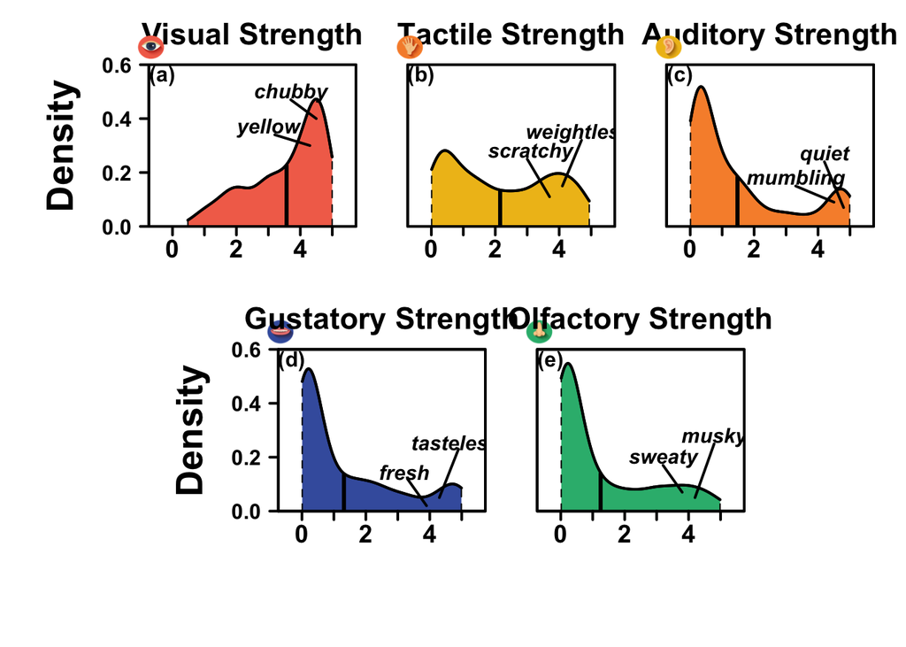

```r
## Plotting parameters:

text_height_factor <- 0.005
cex_text <- 1.45
setup_plots(5)

# Plot 1:
emptyplot(xlim = c(-0.5, 5.5), ylim = c(0, 0.6),
          yaxs = 'i', AB = '(a)', yfactor = 0.07)   # plot 1
mtext(side = 3, line = 1,
      text = 'Visual Strength', cex = 1.4, font = 2)
rasterImage(get(sense_names[1]),
            xleft = -1.1,
            xright = -0.25,
            ybottom = 0.62, ytop = 0.71, xpd = NA)
plot_density(lyn$VisualStrengthMean,
             this_color = mycols[1])
axis(side = 1, at = 0:5,
     labels = 0:5, lwd.ticks = 2, font = 2, cex.axis = 1.75)
axis(side = 2, at = seq(0, 0.6, 0.2),
     las = 2, cex.axis = 1.5, font = 2, lwd.ticks = 2 )
mtext(side = 2, text = "Density",
      line = 4.25, font = 2, cex = 1.7)
box(lwd = 2)
## Add examples:
segments(x0 = 4.5, x1 = 3.7,
         y0 = 0.4, y1 = 0.47, lwd = 2)
text(x = 3.7, y = 0.49 + text_height_factor,
     labels = 'chubby', font = 4, cex = cex_text)
segments(x0 = 4.3, x1 = 3.2,
         y0 = 0.3, y1 = 0.34, lwd = 2)
text(x = 3, y = 0.36 + text_height_factor,
     labels = 'yellow', font = 4, cex = cex_text)
# Plot 2:
emptyplot(xlim = c(-0.5, 5.5), ylim = c(0, 0.6),
          yaxs = 'i', AB = '(b)', yfactor = 0.07)   # plot 2
mtext(side = 3, line = 1,
      text = 'Tactile Strength', cex = 1.4, font = 2)
rasterImage(get(sense_names[2]),
            xleft = -1.1,
            xright = -0.25,
            ybottom = 0.62, 0.71, xpd = NA)
plot_density(lyn$HapticStrengthMean, this_color = mycols[3])
axis(side = 1, at = 0:5, labels = 0:5,
     lwd.ticks = 2, font = 2, cex.axis = 1.75)
box(lwd = 2)
## Add examples:
segments(x0 = 3.8-0.1, x1 = 3.2-0.2,
         y0 = 0.05+0.06, y1 = 0.15+0.1, lwd = 2)
text(x = 3.2-0.1, y = 0.27 + text_height_factor,
     labels = 'scratchy',
     font = 4, cex = cex_text)
segments(x0 = 4.3-0.2, x1 = 4.9-0.2,
         y0 = 0.15, y1 = 0.27+0.05, lwd = 2)
text(x = 4.9-0.3, y = 0.34 + text_height_factor,
     labels = 'weightless',
     font = 4, cex = cex_text)

# Plot 3:
emptyplot(xlim = c(-0.5, 5.5), ylim = c(0, 0.6),
          yaxs = 'i', AB = '(c)', yfactor = 0.07)   # plot 3
mtext(side = 3, line = 1,
      text = 'Auditory Strength', cex = 1.4, font = 2)
rasterImage(get(sense_names[3]),
            xleft = -1.1,
            xright = -0.25,
            ybottom = 0.62, 0.71, xpd = NA)
plot_density(lyn$AuditoryStrengthMean, this_color = mycols[2])
axis(side = 1, at = 0:5,
     labels = 0:5, lwd.ticks = 2, font = 2, cex.axis = 1.75)
box(lwd = 2)
## Add examples:
segments(x0 = 4.8, x1 = 4.2,
         y0 = 0.07, y1 = 0.24, lwd = 2)
text(x = 4.2, y = 0.26 + text_height_factor,
     labels = 'quiet', font = 4, cex = cex_text)
segments(x0 = 4.5, x1 = 3.3,
         y0 = 0.09, y1 = 0.15, lwd = 2)
text(x = 3.3, y = 0.17 + text_height_factor,
     labels = 'mumbling', font = 4, cex = cex_text)

# Plot 4:
emptyplot(xlim = c(-0.5, 5.5), ylim = c(0, 0.6),
          yaxs = 'i', AB = '(d)', yfactor = 0.07)   # plot 4
rasterImage(get(sense_names[4]),
            xleft = -1.1, xright = -0.25,
            ybottom = 0.62, 0.71, xpd = NA)
mtext(side = 3, line = 1,
      text = 'Gustatory Strength', cex = 1.4, font = 2)
plot_density(lyn$GustatoryStrengthMean,
             this_color = mycols[4])
axis(side = 1, at = 0:5,
     labels = 0:5, lwd.ticks = 2, font = 2, cex.axis = 1.75)
axis(side = 2, at = seq(0, 0.6, 0.2),
     las = 2, cex.axis = 1.5, font = 2, lwd.ticks = 2 )
mtext(side = 2, text = "Density",
      line = 4.25, font = 2, cex = 1.7)
box(lwd = 2)
## Add examples:
segments(x0 = 3.8+0.1, x1 = 3.2+0.1,
         y0 = 0.02, y1 = 0.15-0.03, lwd = 2)
text(x = 3.2, y = 0.14 + text_height_factor,
     labels = 'fresh',
    font = 4, cex = cex_text)
segments(x0 = 4.3, x1 = 4.9,
         y0 = 0.05, y1 = 0.25-0.02, lwd = 2)
text(x = 4.8, y = 0.25 + text_height_factor,
     labels = 'tasteless', font = 4, cex = cex_text)

# Plot 5:
emptyplot(xlim = c(-0.5, 5.5),
          ylim = c(0, 0.6), yaxs = 'i',
          AB = '(e)', yfactor = 0.07)   # plot 5
rasterImage(get(sense_names[5]),
            xleft = -1.1, xright = -0.25,
            ybottom = 0.62, 0.71, xpd = NA)
mtext(side = 3, line = 1,
      text = 'Olfactory Strength', cex = 1.4, font = 2)
plot_density(lyn$OlfactoryStrengthMean, this_color = mycols[5])
axis(side = 1, at = 0:5,
     labels = 0:5, lwd.ticks = 2, font = 2, cex.axis = 1.75)
box(lwd = 2)
## Add examples:
segments(x0 = 3.8, x1 = 3.2,
         y0 = 0.05+0.02, y1 = 0.15+0.02, lwd = 2)
text(x = 3.2, y = 0.19 + text_height_factor,
     labels = 'sweaty', font = 4, cex = cex_text)
segments(x0 = 4.3-0.1, x1 = 4.9-0.1,
         y0 = 0.05, y1 = 0.25, lwd = 2)
text(x = 4.9-0.1, y = 0.27 + text_height_factor,
     labels = 'musky', font = 4, cex = cex_text)
```

## Exclusivity against simple baseline

Lynott and Connell (2009, 2013) merely report modality exclusivity values, but they provide no baseline. In the first bit of the analysis, we construct a simple baseline by comparing the actually observed exclusivities against the exclusivity of a hypothetical word that has the average sensory modality strength for each sense.

First, let’s remind ourselves of the average exclusivities for adjectives and nouns:

```r
## Compute modality exclusivity:

round(mean(lyn$ModalityExclusivity), 2)
```

```
## [1] 0.46
```

```r
round(mean(noun$ModalityExclusivity), 2)
```

```
## [1] 0.39
```

The baseline is lower than what is actually observed.

Next, we create the hypothetical exclusivity:

```r
## Baseline modality exclusivity:

adj_means <- apply(lyn[, str_c(mymods, 'StrengthMean')], 2, mean)
round(adj_means, 1)
```

```
##    VisualStrengthMean    HapticStrengthMean  AuditoryStrengthMean
##                   3.6                   2.2                   1.5
## GustatoryStrengthMean OlfactoryStrengthMean
##                   1.3                   1.2
```

```r
print(adj_base <- diff(range(adj_means)) / sum(adj_means))
```

```
## [1] 0.2379961
```

Next, we compare the observed exclusivities against this baseline. We then repeat everything for nouns.

```r
## Compare observed exclusivities against baseline:

wilcox.test(lyn$ModalityExclusivity, mu = adj_base)
```

```
##
##  Wilcoxon signed rank test with continuity correction
##
## data:  lyn$ModalityExclusivity
## V = 88342, p-value < 2.2e-16
## alternative hypothesis: true location is not equal to 0.2379961
```

```r
## Baseline modality exclusivity for nouns:

noun_means <- apply(noun[, str_c(mymods, 'StrengthMean')], 2, mean)
round(noun_means, 1)
```

```
##    VisualStrengthMean    HapticStrengthMean  AuditoryStrengthMean
##                   3.5                   1.9                   2.1
## GustatoryStrengthMean OlfactoryStrengthMean
##                   0.5                   0.8
```

```r
print(noun_base <- diff(range(noun_means)) / sum(noun_means))
```

```
## [1] 0.3380734
```

```r
## Compare observed exclusivities against baseline, nouns:

wilcox.test(noun$ModalityExclusivity, mu = noun_base)
```

```
##
##  Wilcoxon signed rank test with continuity correction
##
## data:  noun$ModalityExclusivity
## V = 59251, p-value < 2.2e-16
## alternative hypothesis: true location is not equal to 0.3380734
```

## Exclusivity against permutation-based baseline

The last baseline was quite simple. It breaks the distributional characteristics of each sensory modality, such as the already observed bimodal characteristics. In the following analysis, we will permute each column (one for each modality) and then compute exclusivities for these randomly permuted words.

```r
## Results vectors for storing randomly generated exclusivities:

nsim <- 1000
l_excl <- numeric(nsim)
n_excl <- numeric(nsim)

## Extract perceptual strength vectors to speed up the loop:

lvis <- lyn$VisualStrengthMean
laud <- lyn$AuditoryStrengthMean
lhap <- lyn$HapticStrengthMean
lolf <- lyn$OlfactoryStrengthMean
lgus <- lyn$GustatoryStrengthMean

nvis <- noun$VisualStrengthMean
naud <- noun$AuditoryStrengthMean
nhap <- noun$HapticStrengthMean
nolf <- noun$OlfactoryStrengthMean
ngus <- noun$GustatoryStrengthMean

## Create a population of modality exclusivities:

set.seed(42)
for (i in 1:nsim) {
    ldf <- data.frame(sample(lvis), sample(laud),
        sample(lhap), sample(lolf), sample(lgus))
    ndf <- data.frame(sample(nvis), sample(naud),
        sample(nhap), sample(nolf), sample(ngus))

    adj_range <- apply(ldf, 1, FUN = function(x) diff(range(x)))
    adj_sum <- apply(ldf, 1, FUN = sum)

    noun_range <- apply(ndf, 1, FUN = function(x) diff(range(x)))
    noun_sum <- apply(ndf, 1, FUN = sum)

    l_excl[i] <- mean(adj_range / adj_sum)
    n_excl[i] <- mean(noun_range / noun_sum)
    }
```

Next, we plot this, with dashed lines for the observed exclusivities.

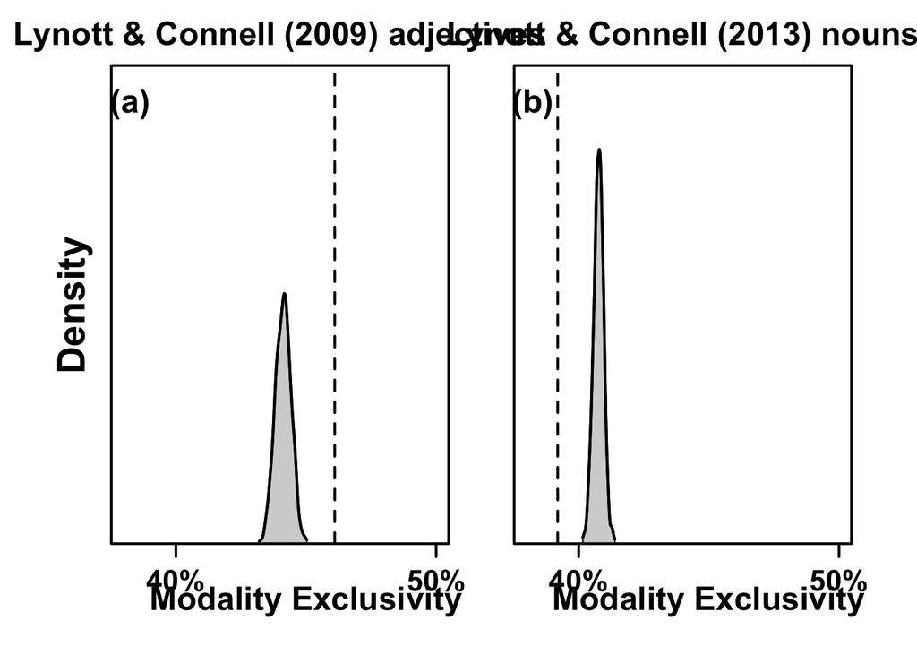

```r
## Make a plot of the exclusivity distributions:

quartz('', 11, 4)
par(mfrow = c(1,2),
    mai = c(0.25, 0.25, 0.25, 0.25),
    omi = c(0.6, 0.6, 0.25, 0.25))

# Plot 1:
plot(1, 1, type = 'n', xlim = c(0.38, 0.5),
     ylim = c(0, 250), yaxs = 'i',
     xlab = '', ylab = '', xaxt = 'n', yaxt = 'n')
plot_AB(xlim = c(0.38, 0.5),
        ylim = c(0, 250), AB = '(a)',
        xfactor = 0.02, yfactor = 0.08)
axis(side = 1, at = c(0.4, 0.5),
     labels = str_c(c(40, 50), '%'),
     font = 2, lwd.ticks = 2, cex.axis = 1.35)
mtext(side = 2, line = 0.8,
      text = 'Density', font = 2, cex = 1.75)
text(labels = 'Modality Exclusivity',
     font = 2, cex = 1.5,
     x = 0.45, y = -30, xpd = NA)
plot_density(na.omit(l_excl), mean = F,
             this_color = 'lightgray')
abline(v = mean(lyn$ModalityExclusivity),
       lwd = 2, lty = 2)
box(lwd = 2)
mtext(side = 3,
      text = 'Lynott & Connell (2009) adjectives',
      font = 2, line = 0.6, cex = 1.5)

# Plot 2:
plot(1, 1, type = 'n',
     xlim = c(0.38, 0.5), ylim = c(0, 250), yaxs = 'i',
     xlab = '', ylab = '', xaxt = 'n', yaxt = 'n')
plot_AB(xlim = c(0.38, 0.5),
        ylim = c(0, 250), AB = '(b)',
        xfactor = 0.02, yfactor = 0.08)
axis(side = 1, at = c(0.4, 0.5),
     labels = str_c(c(40, 50), '%'),
     font = 2, lwd.ticks = 2, cex.axis = 1.35)
text(labels = 'Modality Exclusivity',
     font = 2, cex = 1.5,
     x = 0.45, y = -30, xpd = NA)
plot_density(na.omit(n_excl), mean = F,
             this_color = 'lightgray')
abline(v = mean(noun$ModalityExclusivity),
       lwd = 2, lty = 2)
box(lwd = 2)
mtext(side = 3, text = 'Lynott & Connell (2013) nouns',
      font = 2, line = 0.6, cex = 1.5)
```

```r
## Averages:

mean(l_excl)
```

```
## [1] 0.4412352
```

```r
mean(n_excl)
```

```
## [1] 0.4076222
```

```r
## Significance (simulated p-value):
## (doing one-tailed here but is same as two-tailed
## since no overlap in distributions)

sum((l_excl >= mean(lyn$ModalityExclusivity)))
```

```
## [1] 0
```

```r
sum((n_excl <= mean(noun$ModalityExclusivity)))
```

```
## [1] 0
```

## Permutation-based baseline, separately for each sense

Finally, we repeat this analysis, but this time within modalities. We start by computing the average modality exclusivity per modality and then we look at whether there are significant by-modality differences in exclusivity.

```r
## Get average modality exclusivity per modality:

lyn %>% group_by(DominantModality) %>%
    summarize(Exclusivity = mean(ModalityExclusivity)) %>%
    mutate(Exclusivity = round(Exclusivity, 2)) %>%
    arrange(desc(Exclusivity))
```

```
## # A tibble: 5 x 2
##   DominantModality Exclusivity
##   <chr>                  <dbl>
## 1 Auditory               0.570
## 2 Visual                 0.49
## 3 Olfactory              0.42
## 4 Haptic                 0.37
## 5 Gustatory              0.35
```

```r
## Do a test of this:

kruskal.test(ModalityExclusivity ~ as.factor(DominantModality),
    data = lyn)
```

```
##
##  Kruskal-Wallis rank sum test
##
## data:  ModalityExclusivity by as.factor(DominantModality)
## Kruskal-Wallis chi-squared = 97.085, df = 4, p-value < 2.2e-16
```

Next, we compute the permutations per sensory modality.

```r
## Results vectors for storing randomly generated exclusivities:

nsim <- 1000
vis_excl <- numeric(nsim)
hap_excl <- numeric(nsim)
aud_excl <- numeric(nsim)
gus_excl <- numeric(nsim)
olf_excl <- numeric(nsim)

## Vector of exclusive object names:

vecnames <- str_c(c('vis', 'hap', 'aud', 'gus', 'olf'),
    '_excl')

## Create a population of modality exclusivities:

set.seed(42)
for (i in 1:nsim) {
  for (j in 1:5) {
    df <- filter(lyn, DominantModality == mymods[j])

    lvis <- df$VisualStrengthMean
        laud <- df$AuditoryStrengthMean
        lhap <- df$HapticStrengthMean
        lolf <- df$OlfactoryStrengthMean
        lgus <- df$GustatoryStrengthMean

        ldf <- data.frame(sample(lvis), sample(laud),
            sample(lhap), sample(lolf), sample(lgus))

        adj_range <- apply(ldf, 1, FUN = function(x) diff(range(x)))
        adj_sum <- apply(ldf, 1, FUN = sum)

        this_vec <- get(vecnames[j])
        this_vec[i] <- mean(adj_range / adj_sum)

        assign(vecnames[j], this_vec)
        }
    }
```

Let’s compare the permuted and observed exclusivities.

```r
mean(filter(lyn,
            DominantModality == 'Visual')$ModalityExclusivity)
```

```
## [1] 0.4891868
```

```r
mean(vis_excl)
```

```
## [1] 0.4902824
```

```r
mean(filter(lyn,
            DominantModality == 'Haptic')$ModalityExclusivity)
```

```
## [1] 0.3701926
```

```r
mean(hap_excl)
```

```
## [1] 0.3824742
```

```r
mean(filter(lyn,
            DominantModality == 'Auditory')$ModalityExclusivity)
```

```
## [1] 0.5739076
```

```r
mean(aud_excl)
```

```
## [1] 0.5766537
```

```r
mean(filter(lyn,
            DominantModality == 'Gustatory')$ModalityExclusivity)
```

```
## [1] 0.3492638
```

```r
mean(gus_excl)
```

```
## [1] 0.3562968
```

```r
mean(filter(lyn,
            DominantModality == 'Olfactory')$ModalityExclusivity)
```

```
## [1] 0.4201224
```

```r
mean(olf_excl)
```

```
## [1] 0.4174063
```

Let’s make Kernel density plots of this.

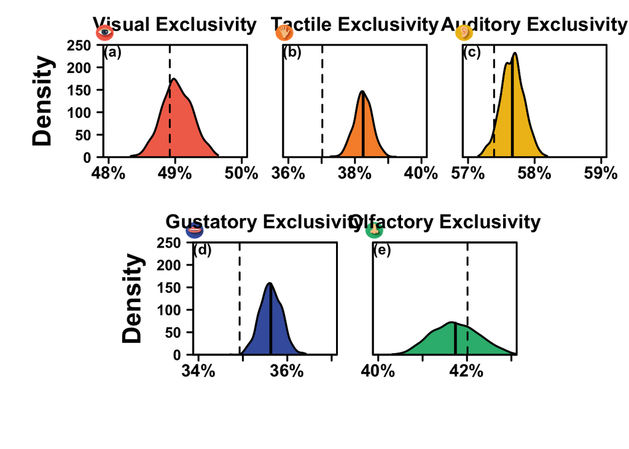

```r
## Functions for plotting symbols with changing x-axes coordinates:

xleft_fnc <- function(xlim = c(0.48, 0.50)) {
  return(xlim[1] - diff(xlim) * 0.1)
    }
xright_fnc <- function(xlim = c(0.48, 0.50)) {
    return(xlim[1] + diff(xlim) * 0.04)
    }

## Make a plot:

setup_plots(5)
# Plot 1:
emptyplot(xlim = c(0.48, 0.50),
          ylim = c(0, 250), yaxs = 'i',
          AB = '(a)', yfactor = 0.07)   # plot 1
mtext(side = 3, line = 1,
      text = 'Visual Exclusivity', cex = 1.3, font = 2)
rasterImage(get(sense_names[1]),
            xleft = xleft_fnc(c(0.48, 0.50)),
            xright = xright_fnc(c(0.48, 0.50)),
            ybottom = 258, ytop = 296, xpd = NA)
plot_density(vis_excl, this_color = mycols[1], mean = F)
axis(side = 1, at = seq(0.48, 0.50, 0.01),
     labels = str_c(seq(0.48, 0.5, 0.01) * 100, '%'),
     lwd.ticks = 2, font = 2, cex.axis = 1.75)
axis(side = 2, at = seq(0, 250, 50),
     las = 2, cex.axis = 1.5, font = 2, lwd.ticks = 2 )
mtext(side = 2, text = "Density",
      line = 4.25, font = 2, cex = 1.7)
box(lwd = 2)
abline(v = mean(mean(filter(lyn, DominantModality == 'Visual')$ModalityExclusivity)), lwd = 2, lty = 2)

# Plot 2:
emptyplot(xlim = c(0.36, 0.40),
          ylim = c(0, 250), yaxs = 'i',
          AB = '(b)', yfactor = 0.07)   # plot 2
mtext(side = 3, line = 1,
      text = 'Tactile Exclusivity', cex = 1.3, font = 2)
rasterImage(get(sense_names[2]),
            xleft = xleft_fnc(c(0.36, 0.40)),
            xright = xright_fnc(c(0.36, 0.40)),
            ybottom = 258, ytop = 296, xpd = NA)
plot_density(hap_excl, this_color = mycols[2])
axis(side = 1, at = seq(0.36, 0.40, 0.01),
     labels = str_c(seq(0.36, 0.40, 0.01) * 100, '%'),
     lwd.ticks = 2, font = 2, cex.axis = 1.75)
box(lwd = 2)
abline(v = mean(mean(filter(lyn, DominantModality == 'Haptic')$ModalityExclusivity)),
       lwd = 2, lty = 2)

# Plot 3:
emptyplot(xlim = c(0.57, 0.59), ylim = c(0, 250), yaxs = 'i',
          AB = '(c)', yfactor = 0.07)   # plot 3
mtext(side = 3, line = 1,
      text = 'Auditory Exclusivity', cex = 1.3, font = 2)
axis(side = 1, at = seq(0.57, 0.59, 0.01),
     labels = str_c(seq(0.57, 0.59, 0.01) * 100, '%'),
     lwd.ticks = 2, font = 2, cex.axis = 1.75)
rasterImage(get(sense_names[3]),
            xleft = xleft_fnc(c(0.57, 0.59)),
            xright = xright_fnc(c(0.57, 0.59)),
            ybottom = 258, ytop = 296, xpd = NA)
plot_density(aud_excl, this_color = mycols[3])
axis(side = 1, at = 0:5,
     labels = 0:5, lwd.ticks = 2, font = 2, cex.axis = 1.75)
box(lwd = 2)
abline(v = mean(mean(filter(lyn, DominantModality == 'Auditory')$ModalityExclusivity)),
       lwd = 2, lty = 2)

# Plot 4:
emptyplot(xlim = c(0.34, 0.37),
          ylim = c(0, 250), yaxs = 'i',
          AB = '(d)', yfactor = 0.07)   # plot 4
axis(side = 1, at = seq(0.34, 0.37, 0.01),
     labels = str_c(seq(0.34, 0.37, 0.01) * 100, '%'),
     lwd.ticks = 2, font = 2, cex.axis = 1.75)
rasterImage(get(sense_names[4]),
            xleft = xleft_fnc(c(0.34, 0.37)),
            xright = xright_fnc(c(0.34, 0.37)),
            ybottom = 258, ytop = 296, xpd = NA)
mtext(side = 3, line = 1,
      text = 'Gustatory Exclusivity', cex = 1.3, font = 2)
plot_density(gus_excl, this_color = mycols[4])
axis(side = 1, at = 0:5,
     labels = 0:5, lwd.ticks = 2, font = 2, cex.axis = 1.75)
axis(side = 2, at = seq(0, 250, 50),
     las = 2, cex.axis = 1.5, font = 2, lwd.ticks = 2 )
mtext(side = 2, text = "Density",
      line = 4.25, font = 2, cex = 1.7)
box(lwd = 2)
abline(v = mean(mean(filter(lyn, DominantModality == 'Gustatory')$ModalityExclusivity)),
       lwd = 2, lty = 2)

# Plot 5:
emptyplot(xlim = c(0.4, 0.43),
          ylim = c(0, 250), yaxs = 'i',
          AB = '(e)', yfactor = 0.07)   # plot 5
axis(side = 1, at = seq(0.4, 0.43, 0.01),
     labels = str_c(seq(0.4, 0.43, 0.01) * 100, '%'),
     lwd.ticks = 2, font = 2, cex.axis = 1.75)
rasterImage(get(sense_names[5]),
            xleft = xleft_fnc(c(0.4, 0.43)),
            xright = xright_fnc(c(0.4, 0.43)),
            ybottom = 258, ytop = 296, xpd = NA)
mtext(side = 3, line = 1,
      text = 'Olfactory Exclusivity', cex = 1.3, font = 2)
plot_density(olf_excl, this_color = mycols[5])
axis(side = 1, at = 0:5,
     labels = 0:5, lwd.ticks = 2, font = 2, cex.axis = 1.75)
box(lwd = 2)
abline(v = mean(mean(filter(lyn, DominantModality == 'Olfactory')$ModalityExclusivity)),
       lwd = 2, lty = 2)
```

Check permutation-based p-values:

```r
## Check p-value of taste and sound:

nsmaller <- sum(gus_excl <= mean(filter(lyn, DominantModality == 'Gustatory')$ModalityExclusivity))
nsmaller / nsim * 2
```

```
## [1] 0.002
```

```r
nsmaller <- sum(aud_excl <= mean(filter(lyn, DominantModality == 'Auditory')$ModalityExclusivity))
nsmaller / nsim * 2     # but two-tailed * 2
```

```
## [1] 0.104
```

This completes the analyses presented in Chapter 12.